# Data Cleaning

## Recap on summarization

- `summary(x)`: quantile information
- `count(x)`: what unique values do you have?
  - `distinct()`: what are the distinct values?
  - `n_distinct()` with `pull()`: how many distinct values?
- `group_by()`: changes all subsequent functions
  - combine with `summarize()` to get statistics per group
  - combine with `mutate()` to add column
- `summarize()` with `n()` gives the count (NAs included)

📃[Day 4 Cheatsheet](https://daseh.org/modules/cheatsheets/Day-4.pdf)

## Recap on data classes

- There are two types of number class objects: integer and double
- Logic class objects only have `TRUE` or `FALSE` (without quotes)
- `class()` can be used to test the class of an object x
- `as.CLASS_NAME(x)` can be used to change the class of an object x
- Factors are a special character class that has levels - more on that soon!
- tibbles show column classes!
- two dimensional object classes include: data frames, tibbles, matrices, and lists
- Dates can be handled with the `lubridate` package
- Make sure you choose the right function for the way the date is formatted!

📃[Day 4 Cheatsheet](https://daseh.org/modules/cheatsheets/Day-4.pdf)

## Data Cleaning

In general, data cleaning is a process of investigating your data for inaccuracies, or recoding it in a way that makes it more manageable.

⚠️ MOST IMPORTANT RULE - LOOK 👀 AT YOUR DATA! ⚠️

## Dealing with Missing Data

## Missing data types

One of the most important aspects of data cleaning is missing values.

Types of “missing” data:

- `NA` - general missing data
- `NaN` - stands for “**N**ot **a** **N**umber”, happens when you do 0/0.
- `Inf` and `-Inf` - Infinity, happens when you divide a positive number (or negative number) by 0.

## Finding Missing data

- `is.na` - looks for `NAN` and `NA`
- `is.nan`- looks for `NAN`
- `is.infinite` - looks for Inf or -Inf

```r
test <- c(0,NA, -1)
test/0
```

```
[1]  NaN   NA -Inf
```

```r
test <- test/0
is.na(test)
```

```
[1]  TRUE  TRUE FALSE
```

```r
is.nan(test)
```

```
[1]  TRUE FALSE FALSE
```

```r
is.infinite(test)
```

```
[1] FALSE FALSE  TRUE
```

## Useful checking functions

`any()` can help you check if there are any `NA` values in a vector

```r
test
```

```
[1]  NaN   NA -Inf
```

```r
any(is.na(test))
```

```
[1] TRUE
```

## Finding `NA` values with `count()`

Check the values for your variables, are they what you expect?

`count()` is a great option because it helps you check if rare values make sense.

Let’s look at the CO heat-related ER visits dataset again.

```r
er <- read_csv(file =
    "https://daseh.org/data/CO_ER_heat_visits.csv")
er %>% count(visits)
```

```
# A tibble: 37 × 2
   visits     n
    <dbl> <int>
 1      0   339
 2     11     2
 3     12     5
 4     13     8
 5     14     3
 6     15     2
 7     16     3
 8     17     3
 9     18     5
10     19     7
# ℹ 27 more rows
```

## `naniar`

Sometimes you need to look at lots of data though… the [`naniar` package](https://cran.r-project.org/web/packages/naniar/vignettes/getting-started-w-naniar.html) is a good option.

```r
#install.packages("naniar")
library(naniar)
```

[figure not shown]

“Artwork by @allison_horst”. https://allisonhorst.com/

## naniar: `pct_complete()`

This can tell you if there are missing values in the dataset.

```r
pct_complete(er)
```

```
[1] 73.65451
```

Or for a particular variable:

```r
er %>% select(visits) %>%
  pct_complete()
```

```
[1] 60.54688
```

```r
er %>% select(rate) %>%
  pct_complete()
```

```
[1] 60.54688
```

## naniar:`miss_var_summary()`

To get the percent missing (and counts) for each variable as a table, use this function:

```r
miss_var_summary(er)
```

```
# A tibble: 6 × 3
  variable  n_miss pct_miss
  <chr>      <int>    <num>
1 lower95cl    304     39.6
2 upper95cl    304     39.6
3 rate         303     39.5
4 visits       303     39.5
5 county         0      0
6 year           0      0
```

## `naniar` plots

The `gg_miss_var()` function creates a nice plot about the number of missing values for each variable, (need a data frame).

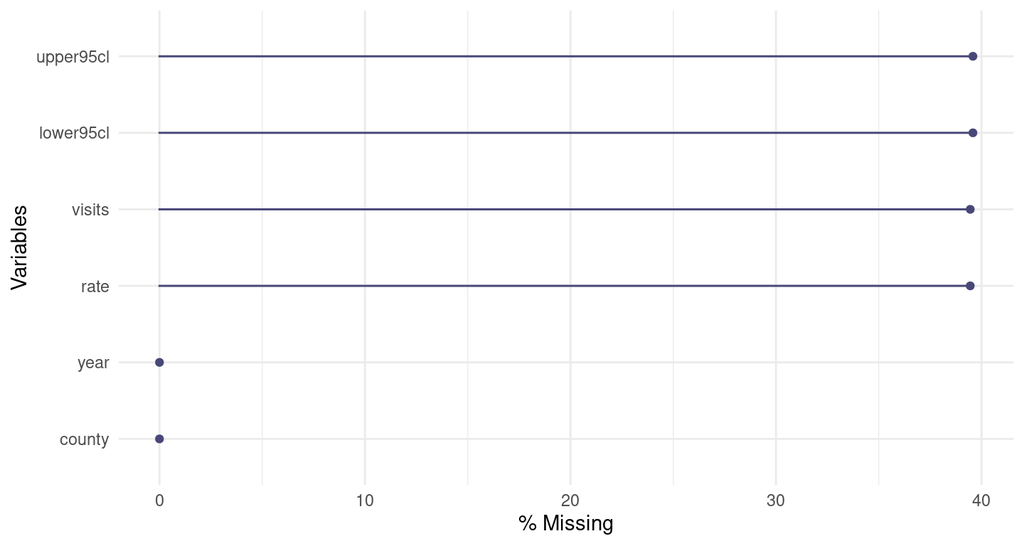

```r
gg_miss_var(er, show_pct = TRUE)
```

## Missing Data Issues

Recall that mathematical operations with `NA` often result in `NA`s.

```r
sum(c(1,2,3,NA))
```

```
[1] NA
```

```r
mean(c(1,2,3,NA))
```

```
[1] NA
```

```r
median(c(1,2,3,NA))
```

```
[1] NA
```

## Missing Data Issues

This is also true for logical data. Recall that `TRUE` is evaluated as 1 and `FALSE` is evaluated as 0.

```r
x <- c(TRUE, TRUE, TRUE, TRUE, FALSE, NA)
sum(x)
```

```
[1] NA
```

```r
sum(x, na.rm = TRUE)
```

```
[1] 4
```

## filter() and missing data

Be **careful** with missing data using subsetting!

**`filter()` removes missing values by default.** Because R can’t tell for sure if an `NA` value meets the condition. To keep them need to add `is.na()` conditional.

Think about if this is OK or not - it depends on your data!

## filter() and missing data

What if NA values represent values that are so low it is undetectable?

Filter will drop them from the data.

```r
er %>% filter(visits > 0)
```

```
# A tibble: 126 × 6
   county  rate lower95cl upper95cl visits  year
   <chr>  <dbl>     <dbl>     <dbl>  <dbl> <dbl>
 1 Adams   6.73     NA         9.24     29  2011
 2 Adams   4.84      2.85     NA        23  2012
 3 Adams   6.84      4.36      9.31     31  2013
 4 Adams   3.08      1.71      4.85     15  2014
 5 Adams   3.36      1.89      5.23     16  2015
 6 Adams   8.85      6.12     11.6      42  2016
 7 Adams   6.63      4.29      8.98     32  2017
 8 Adams   7.11      4.77      9.44     37  2018
 9 Adams   6.76      4.53      8.99     36  2019
10 Adams   4.76      2.82      6.70     24  2020
# ℹ 116 more rows
```

## filter() and missing data

`is.na()` can help us keep them.

```r
er %>% filter(visits > 0 | is.na(visits))
```

```
# A tibble: 429 × 6
   county  rate lower95cl upper95cl visits  year
   <chr>  <dbl>     <dbl>     <dbl>  <dbl> <dbl>
 1 Adams   6.73     NA         9.24     29  2011
 2 Adams   4.84      2.85     NA        23  2012
 3 Adams   6.84      4.36      9.31     31  2013
 4 Adams   3.08      1.71      4.85     15  2014
 5 Adams   3.36      1.89      5.23     16  2015
 6 Adams   8.85      6.12     11.6      42  2016
 7 Adams   6.63      4.29      8.98     32  2017
 8 Adams   7.11      4.77      9.44     37  2018
 9 Adams   6.76      4.53      8.99     36  2019
10 Adams   4.76      2.82      6.70     24  2020
# ℹ 419 more rows
```

## To remove **rows** with `NA` values for a **variable** use `drop_na()`

A function from the `tidyr` package. (Need a data frame to start!)

Disclaimer: Don’t do this unless you have thought about if dropping `NA` values makes sense based on knowing what these values mean in your data. **Also consider if you need those rows for values for other variables.**

```r
dim(er)
```

```
[1] 768   6
```

```r
er_drop <- er %>% drop_na(lower95cl)
dim(er_drop)
```

```
[1] 464   6
```

## Let’s take a look

Can still have NAs for other columns

```r
er_drop
```

```
# A tibble: 464 × 6
   county  rate lower95cl upper95cl visits  year
   <chr>  <dbl>     <dbl>     <dbl>  <dbl> <dbl>
 1 Adams   4.84      2.85     NA        23  2012
 2 Adams   6.84      4.36      9.31     31  2013
 3 Adams   3.08      1.71      4.85     15  2014
 4 Adams   3.36      1.89      5.23     16  2015
 5 Adams   8.85      6.12     11.6      42  2016
 6 Adams   6.63      4.29      8.98     32  2017
 7 Adams   7.11      4.77      9.44     37  2018
 8 Adams   6.76      4.53      8.99     36  2019
 9 Adams   4.76      2.82      6.70     24  2020
10 Adams   6.93      4.61      9.25     35  2021
# ℹ 454 more rows
```

## To remove rows with `NA` values for a **data frame** use `drop_na()`

This function of the `tidyr` package drops rows with **any** missing data in **any** column when used on a df.

```r
er_drop <- er %>% drop_na()
er_drop
```

```
# A tibble: 463 × 6
   county  rate lower95cl upper95cl visits  year
   <chr>  <dbl>     <dbl>     <dbl>  <dbl> <dbl>
 1 Adams   6.84      4.36      9.31     31  2013
 2 Adams   3.08      1.71      4.85     15  2014
 3 Adams   3.36      1.89      5.23     16  2015
 4 Adams   8.85      6.12     11.6      42  2016
 5 Adams   6.63      4.29      8.98     32  2017
 6 Adams   7.11      4.77      9.44     37  2018
 7 Adams   6.76      4.53      8.99     36  2019
 8 Adams   4.76      2.82      6.70     24  2020
 9 Adams   6.93      4.61      9.25     35  2021
10 Adams   8.23      5.81     10.6      45  2022
# ℹ 453 more rows
```

## Drop **columns** with any missing values

Use the `miss_var_which()` function from `naniar`

```r
miss_var_which(er)# which columns have missing values
```

```
[1] "rate"      "lower95cl" "upper95cl" "visits"
```

## Drop **columns** with any missing values

`miss_var_which` and function from `naniar` (need a data frame)

```r
er_drop <- er %>% select(!miss_var_which(er))
er_drop
```

```
# A tibble: 768 × 2
   county  year
   <chr>  <dbl>
 1 Adams   2011
 2 Adams   2012
 3 Adams   2013
 4 Adams   2014
 5 Adams   2015
 6 Adams   2016
 7 Adams   2017
 8 Adams   2018
 9 Adams   2019
10 Adams   2020
# ℹ 758 more rows
```

## Change a value to be `NA`

Let’s say we think that all 0 values should be `NA`.

Maybe we think the person who entered the CO heat-related ER visits data made a mistake in how they coded missing data.

```r
er %>% count(visits)
```

```
# A tibble: 37 × 2
   visits     n
    <dbl> <int>
 1      0   339
 2     11     2
 3     12     5
 4     13     8
 5     14     3
 6     15     2
 7     16     3
 8     17     3
 9     18     5
10     19     7
# ℹ 27 more rows
```

## Change a value to be `NA`

The `na_if()` function of `dplyr` can be helpful for changing all 0 values to `NA`.

```r
er_nozero <- er %>%
  mutate(visits = na_if(visits, 0))

er_nozero %>% count(visits)
```

```
# A tibble: 36 × 2
   visits     n
    <dbl> <int>
 1     11     2
 2     12     5
 3     13     8
 4     14     3
 5     15     2
 6     16     3
 7     17     3
 8     18     5
 9     19     7
10     20     2
# ℹ 26 more rows
```

## Change `NA` to be a value

The `replace_na()` function (part of the `tidyr` package), can do the opposite of `na_if()`. (note that you must use numeric values as replacement - we will show how to replace with character strings soon)

```r
er %>%
  mutate(visits = replace_na(visits, 0)) %>%
  count(visits)
```

```
# A tibble: 36 × 2
   visits     n
    <dbl> <int>
 1      0   642
 2     11     2
 3     12     5
 4     13     8
 5     14     3
 6     15     2
 7     16     3
 8     17     3
 9     18     5
10     19     7
# ℹ 26 more rows
```

## Think about `NA`

THINK ABOUT YOUR DATA FIRST!

⚠️ Sometimes removing `NA` values leads to distorted math - be careful!

⚠️ Think about what your `NA` means for your data (are you sure ?).

- Is an `NA` for values so low they could not be reported?
- Or is it if it was too low and also if there was a different issue (like no one reported)?

## Think about `NA`

If it is something more like a zero then you might want it included in your data like a zero instead of an `NA`.

Example: - survey reports `NA` if student has never tried cigarettes - survey reports 0 if student has tried cigarettes but did not smoke that week

⚠️ You might want to keep the `NA` values so that you know the original sample size.

## Word of caution

⚠️ Calculating percentages will give you a different result depending on your choice to include NA values.!

This is because the denominator changes.

## Word of caution - Percentages with `NA`

```r
count(er, visits) %>% mutate(percent = (n/(sum(n)) *100))
```

```
# A tibble: 37 × 3
   visits     n percent
    <dbl> <int>   <dbl>
 1      0   339  44.1
 2     11     2   0.260
 3     12     5   0.651
 4     13     8   1.04
 5     14     3   0.391
 6     15     2   0.260
 7     16     3   0.391
 8     17     3   0.391
 9     18     5   0.651
10     19     7   0.911
# ℹ 27 more rows
```

## Word of caution - Percentages with `NA`

```r
er %>% drop_na(visits) %>%
  count(visits) %>% mutate(percent = (n/(sum(n)) *100))
```

```
# A tibble: 36 × 3
   visits     n percent
    <dbl> <int>   <dbl>
 1      0   339  72.9
 2     11     2   0.430
 3     12     5   1.08
 4     13     8   1.72
 5     14     3   0.645
 6     15     2   0.430
 7     16     3   0.645
 8     17     3   0.645
 9     18     5   1.08
10     19     7   1.51
# ℹ 26 more rows
```

Should you be dividing by the total count with `NA` values included?  
It depends on your data and what `NA` might mean.  
Pay attention to your data and your `NA` values!

## Don’t forget about the common issues

- Extra or Missing commas
- Extra or Missing parentheses
- Case sensitivity
- Spelling

## GUT CHECK: What function can be used to remove NA values from a full dataframe or for an individual column?

A. `drop_nulls()`

B. `drop_na()`

C. `rem_na()`

## GUT CHECK: How can you keep NA values when using `filter`?

A. include `| is.na()`

B. include `& is.na()`

## Summary

- `is.na()`,`any(is.na())`, `all(is.na())`,`count()`, and functions from `naniar` like `gg_miss_var()` and `miss_var_summary` can help determine if we have `NA` values
- `miss_var_which()` can help you drop columns that have any missing values.
- `filter()` automatically removes `NA` values - can’t confirm or deny if condition is met (need `| is.na()` to keep them)
- `drop_na()` can help you remove `NA` values from a variable or an entire data frame
- `NA` values can change your calculation results
- think about what `NA` values represent - don’t drop them if you shouldn’t
- `na_if()` will make `NA` values for a particular value
- `replace_na()` will replace `NA values with a particular value

## Lab Part 1

🏠 [Class Website](https://daseh.org/)  
💻 [Lab](https://daseh.org/modules/Data_Cleaning/lab/Data_Cleaning_Lab.Rmd). 📃 [Day 5 Cheatsheet](https://daseh.org/modules/cheatsheets/Day-5.pdf)

## Recoding Variables

## Example of Recoding

Let’s upload some practice data about microplastics. Maybe we measured the level of microplastics in someone who eats a fish versus someone who is a vegetarian.

https://www.medicalnewstoday.com/articles/what-do-we-know-about-microplastics-in-food#Common-microplastics-in-food https://www.sciencedirect.com/science/article/pii/S0045653523028072 https://www.ncbi.nlm.nih.gov/pmc/articles/PMC5708064/

```r
plastics <- read_csv(file =
    "https://daseh.org/data/microplastics_in_blood.csv")
```

```
Rows: 12 Columns: 4
── Column specification ────────────────────────────────────────────────────────
Delimiter: ","
chr (2): Foods, microplastic
dbl (2): blood_level_start_nM, blood_level_change_nM

ℹ Use `spec()` to retrieve the full column specification for this data.
ℹ Specify the column types or set `show_col_types = FALSE` to quiet this message.
```

## microplastics data

```r
plastics
```

```
# A tibble: 12 × 4
   Foods microplastic blood_level_start_nM blood_level_change_nM
   <chr> <chr>                       <dbl>                 <dbl>
 1 A     Dioxin                          1                   2.5
 2 B     Dioxin                          7                   2.5
 3 B     Other                           2                   0.5
 4 A     Bisphenol A                     3                  -0.5
 5 B     BPA                             5                   0.5
 6 B     dioxin                          8                   0.5
 7 A     bpa                             6                   2.5
 8 B     O                               5                   3.5
 9 B     dioxin                          2                   0.5
10 A     bpa                             1                   1.5
11 B     BPA                             7                   1.5
12 B     O                               3                   2.5
```

## Oh dear…

This needs lots of recoding.

```r
plastics %>%
  count(microplastic)
```

```
# A tibble: 7 × 2
  microplastic     n
  <chr>        <int>
1 BPA              2
2 Bisphenol A      1
3 Dioxin           2
4 O                2
5 Other            1
6 bpa              2
7 dioxin           2
```

## `dplyr` can help!

Using Excel to find all of the different ways `microplastic` has been coded, could be hectic! In `dplyr` you can use the `case_when` function.

## Or you can use `case_when()`

The `case_when()` function of `dplyr` can help us to do this as well.

It is more flexible and powerful.

(need `mutate` here too!)

## Or you can use `case_when()`

Need quotes for conditions and new values!

```r
plastics %>%
  mutate(microplastic_recoded = case_when(
                               microplastic == "O" ~ "Other",
                               microplastic == "Bisphenol A" ~ "BPA",
                               microplastic == "bpa" ~ "BPA",
                               microplastic =="dioxin" ~"Dioxin"))  %>%
  count(microplastic, microplastic_recoded)
```

```
# A tibble: 7 × 3
  microplastic microplastic_recoded     n
  <chr>        <chr>                <int>
1 BPA          <NA>                     2
2 Bisphenol A  BPA                      1
3 Dioxin       <NA>                     2
4 O            Other                    2
5 Other        <NA>                     1
6 bpa          BPA                      2
7 dioxin       Dioxin                   2
```

## What happened?

We seem to have `NA` values!

We didn’t specify what happens to values that were already `Other` or `Dioxin` or `BPA`.

```r
plastics %>%
  mutate(microplastic_recoded = case_when(
                               microplastic == "O" ~ "Other",
                               microplastic == "Bisphenol A" ~ "BPA",
                               microplastic == "bpa" ~ "BPA",
                               microplastic =="dioxin" ~"Dioxin"))  %>%
  count(microplastic, microplastic_recoded)
```

## `case_when()` drops unspecified values

Note that automatically values not reassigned explicitly by `case_when()` will be `NA` unless otherwise specified.

```r
# General Format - this is not code!
{data_input} %>%
  mutate({variable_to_fix} = case_when({Variable_fixing}
             /some condition/ ~ {value_for_con},
                         TRUE ~ {value_for_not_meeting_condition})
```

{value_for_not_meeting_condition} could be something new or it can be the original values of the column

## case_when with TRUE ~ original variable name

```r
plastics %>%
  mutate(microplastic_recoded = case_when(
                               microplastic == "O" ~ "Other",
                               microplastic == "Bisphenol A" ~ "BPA",
                               microplastic == "bpa" ~ "BPA",
                               microplastic =="dioxin" ~"Dioxin",
                                TRUE ~ microplastic)) %>%
  count(microplastic_recoded)
```

```
# A tibble: 3 × 2
  microplastic_recoded     n
  <chr>                <int>
1 BPA                      5
2 Dioxin                   4
3 Other                    3
```

## Typically it is good practice to include the TRUE statement

You never know if you might be missing something - and if a value already was an NA it will stay that way.

```r
plastics %>%
  mutate(microplastic_recoded = case_when(
                               microplastic == "O" ~ "Other",
                               microplastic == "Bisphenol A" ~ "BPA",
                               microplastic == "bpa" ~ "BPA",
                               microplastic =="dioxin" ~"Dioxin",
                               TRUE ~ microplastic)) %>%
  count(microplastic, microplastic_recoded)
```

## case_when() can also overwrite/update a variable

You need to specify what we want in the first part of `mutate`.

```r
plastics %>%
  mutate(microplastic = case_when(
                              microplastic == "Bisphenol A" ~ "BPA",
                              microplastic == "bpa" ~ "BPA",
                              microplastic == "dioxin" ~"Dioxin",
                              microplastic == "O" ~ "Other",
                               TRUE ~ microplastic)) %>%
  count(microplastic)
```

```
# A tibble: 3 × 2
  microplastic     n
  <chr>        <int>
1 BPA              5
2 Dioxin           4
3 Other            3
```

## More complicated case_when()

`case_when` can do complicated statements and can match many patterns at a time.

```r
plastics %>%
  mutate(microplastic_recoded = case_when(
    microplastic %in% c("dioxin", "Dioxin") ~ "dioxin",
    microplastic %in% c("BPA", "bpa", "Bisphenol A") ~ "BPA",
    microplastic %in% c("O", "Other") ~ "Other",
                      TRUE ~ microplastic)) %>%

  count(microplastic, microplastic_recoded)
```

```
# A tibble: 7 × 3
  microplastic microplastic_recoded     n
  <chr>        <chr>                <int>
1 BPA          BPA                      2
2 Bisphenol A  BPA                      1
3 Dioxin       dioxin                   2
4 O            Other                    2
5 Other        Other                    1
6 bpa          BPA                      2
7 dioxin       dioxin                   2
```

## Another reason for `case_when()`

`case_when` can do very sophisticated comparisons!

Here we create a new variable called `Effect`.

```r
plastics <- plastics %>%
      mutate(Effect = case_when(
                    blood_level_change_nM > 0 ~ "Increase",
                    blood_level_change_nM == 0 ~ "Same",
                    blood_level_change_nM < 0 ~ "Decrease"))

head(plastics)
```

```
# A tibble: 6 × 5
  Foods microplastic blood_level_start_nM blood_level_change_nM Effect
  <chr> <chr>                       <dbl>                 <dbl> <chr>
1 A     Dioxin                          1                   2.5 Increase
2 B     Dioxin                          7                   2.5 Increase
3 B     Other                           2                   0.5 Increase
4 A     Bisphenol A                     3                  -0.5 Decrease
5 B     BPA                             5                   0.5 Increase
6 B     dioxin                          8                   0.5 Increase
```

## Now it is easier to see what is happening

```r
plastics %>%
  count(Foods, Effect)
```

```
# A tibble: 3 × 3
  Foods Effect       n
  <chr> <chr>    <int>
1 A     Decrease     1
2 A     Increase     3
3 B     Increase     8
```

## GUT CHECK: we need to use what function with `case_when()` to modify or create a new variable?

A. `modify()`

B. `select()`

C. `mutate()`

## GUT CHECK: If we want all unspecified values to remain the same with `case_when()`, how should we complete the `TRUE ~` statement?

A. With the name of the variable we are modifying or using as source

B. With the word “same”

## Working with strings

## Strings in R

- R can do much more than find exact matches for a whole string!

[figure not shown]

## The `stringr` package

The `stringr` package:

- Modifying or finding **part** or all of a character string
- We will not cover `grep` or `gsub` - base R functions
  - are used on forums for answers
- Almost all functions start with `str_*`

## `stringr`

`str_detect`, and `str_replace` search for matches to argument pattern within each element of a **character vector** (not data frame or tibble!).

- `str_detect` - returns `TRUE` if `pattern` is found
- `str_replace` - replaces `pattern` with `replacement`

## `str_detect()`

The `string` argument specifies what to check  
The `pattern` argument specifies what to check for (case sensitive)

```r
Effect <- pull(plastics) %>% head(n = 6)
Effect
```

```
[1] "Increase" "Increase" "Increase" "Decrease" "Increase" "Increase"
```

```r
str_detect(string = Effect, pattern = "d")
```

```
[1] FALSE FALSE FALSE FALSE FALSE FALSE
```

```r
str_detect(string = Effect, pattern = "D")
```

```
[1] FALSE FALSE FALSE  TRUE FALSE FALSE
```

## `str_replace()`

The `string` argument specifies what to check  
The `pattern` argument specifies what to check for  
The `replacement` argument specifies what to replace the pattern with

```r
str_replace(string = Effect, pattern = "D", replacement = "d")
```

```
[1] "Increase" "Increase" "Increase" "decrease" "Increase" "Increase"
```

## `st_replace()` only replaces the first instance of the pattern in each value

`str_replace_all()` can be used to replace all instances within each value

```r
str_replace(string = Effect, pattern = "e", replacement = "E")
```

```
[1] "IncrEase" "IncrEase" "IncrEase" "DEcrease" "IncrEase" "IncrEase"
```

```r
str_replace_all(string = Effect, pattern = "e", replacement = "E")
```

```
[1] "IncrEasE" "IncrEasE" "IncrEasE" "DEcrEasE" "IncrEasE" "IncrEasE"
```

## Subsetting part of a string

`str_sub()` allows you to subset part of a string  
The `string` argument specifies what strings to work with  
The `start` argument specifies position of where to start  
The `end` argument specifies position of where to end

```r
str_sub(string = Effect, start = 1, end = 3)
```

```
[1] "Inc" "Inc" "Inc" "Dec" "Inc" "Inc"
```

## `filter` and `stringr` functions

```r
head(plastics, n = 4)
```

```
# A tibble: 4 × 5
  Foods microplastic blood_level_start_nM blood_level_change_nM Effect
  <chr> <chr>                       <dbl>                 <dbl> <chr>
1 A     Dioxin                          1                   2.5 Increase
2 B     Dioxin                          7                   2.5 Increase
3 B     Other                           2                   0.5 Increase
4 A     Bisphenol A                     3                  -0.5 Decrease
```

```r
plastics %>%
  filter(str_detect(string = microplastic,
                    pattern = "B"))
```

```
# A tibble: 3 × 5
  Foods microplastic blood_level_start_nM blood_level_change_nM Effect
  <chr> <chr>                       <dbl>                 <dbl> <chr>
1 A     Bisphenol A                     3                  -0.5 Decrease
2 B     BPA                             5                   0.5 Increase
3 B     BPA                             7                   1.5 Increase
```

## OK back to our original problem

```r
count(plastics, microplastic)
```

```
# A tibble: 7 × 2
  microplastic     n
  <chr>        <int>
1 BPA              2
2 Bisphenol A      1
3 Dioxin           2
4 O                2
5 Other            1
6 bpa              2
7 dioxin           2
```

## `case_when()` made an improvement

But we still might miss a strange value - like a misspelling

```r
plastics %>%
  mutate(microplastic_recoded = case_when(
    microplastic %in% c("Dioxin", "dioxin") ~ "Dioxin",
    microplastic %in% c("BPA", "bpa", "Bisphenol A") ~ "BPA",
    microplastic %in% c("O", "Other") ~ "Other",
    TRUE ~ microplastic))
```

## `case_when()` improved with `stringr`

`^` indicates the beginning of a character string `$` indicates the end

```r
plastics %>%
  mutate(microplastic_recoded = case_when(
    str_detect(string = microplastic, pattern = "^b|^B") ~ "BPA",
    str_detect(string = microplastic, pattern = "^o|^O") ~ "Other",
    str_detect(string = microplastic, pattern = "^d|^D") ~ "Dioxin",
    TRUE ~ microplastic)) %>%
  count(microplastic, microplastic_recoded)
```

```
# A tibble: 7 × 3
  microplastic microplastic_recoded     n
  <chr>        <chr>                <int>
1 BPA          BPA                      2
2 Bisphenol A  BPA                      1
3 Dioxin       Dioxin                   2
4 O            Other                    2
5 Other        Other                    1
6 bpa          BPA                      2
7 dioxin       Dioxin                   2
```

This is a more robust solution! It will catch typos as long as the first letter is correct.

## That’s better!

[figure not shown]

## GUT CHECK: What `stringr` function helps us find a string pattern?

A. `str_replace()`

B. `str_find()`

C. `str_detect()`

## Separating and uniting data

## Uniting columns

The `unite()` function can help combine columns  
The `col` argument specifies new column name  
The `sep` argument specifies what separator to use when combining -default is “_” The `remove` argument specifies if you want to drop the old columns

```r
plastics_comb <- plastics %>%
  unite(Foods, Effect, col = "change", remove = TRUE)
```

```r
plastics_comb
```

```
# A tibble: 12 × 4
   change     microplastic blood_level_start_nM blood_level_change_nM
   <chr>      <chr>                       <dbl>                 <dbl>
 1 A_Increase Dioxin                          1                   2.5
 2 B_Increase Dioxin                          7                   2.5
 3 B_Increase Other                           2                   0.5
 4 A_Decrease Bisphenol A                     3                  -0.5
 5 B_Increase BPA                             5                   0.5
 6 B_Increase dioxin                          8                   0.5
 7 A_Increase bpa                             6                   2.5
 8 B_Increase O                               5                   3.5
 9 B_Increase dioxin                          2                   0.5
10 A_Increase bpa                             1                   1.5
11 B_Increase BPA                             7                   1.5
12 B_Increase O                               3                   2.5
```

## Separating columns based on a separator

The `separate()` function from `tidyr` can split a column into multiple columns.  
The `col` argument specifies what column to work with  
The `into` argument specifies names of new columns  
The `sep` argument specifies what to separate by

```r
plastics_comb <- plastics_comb %>%
  separate(col = change, into = c("Foods", "Change"), sep = "_" )
plastics_comb
```

```
# A tibble: 12 × 5
   Foods Change   microplastic blood_level_start_nM blood_level_change_nM
   <chr> <chr>    <chr>                       <dbl>                 <dbl>
 1 A     Increase Dioxin                          1                   2.5
 2 B     Increase Dioxin                          7                   2.5
 3 B     Increase Other                           2                   0.5
 4 A     Decrease Bisphenol A                     3                  -0.5
 5 B     Increase BPA                             5                   0.5
 6 B     Increase dioxin                          8                   0.5
 7 A     Increase bpa                             6                   2.5
 8 B     Increase O                               5                   3.5
 9 B     Increase dioxin                          2                   0.5
10 A     Increase bpa                             1                   1.5
11 B     Increase BPA                             7                   1.5
12 B     Increase O                               3                   2.5
```

## Summary

- `case_when()` requires `mutate()` when working with dataframes/tibbles
- `case_when()` can recode **entire values** based on **conditions** (need quotes for conditions and new values)
  - remember `case_when()` needs `TRUE ~ varaible` to keep values that aren’t specified by conditions, otherwise will be `NA`

**Note:** you might see the `recode()` function, it only does some of what `case_when()` can do, so we skipped it, but it is in the extra slides at the end.

## Summary continued

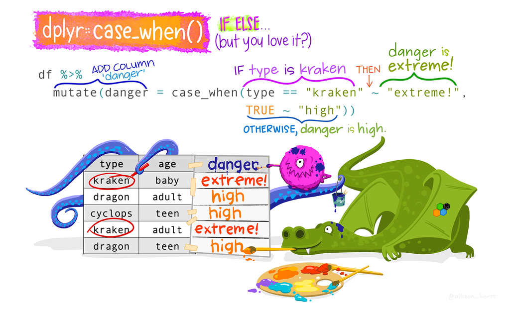

“Artwork by @allison_horst”. https://allisonhorst.com/

## Summary Continued

- `stringr` package has great functions for looking for specific **parts of values** especially `filter()` and `str_detect()` combined
- `stringr` also has other useful string functions like `str_detect()` (finding patterns in a column or vector), `str_subset()` (parsing text), `str_replace()` (replacing the first instance in values), `str_replace_all()` (replacing all instances in each value) and **more**!
- `separate()` can split columns into additional columns
- `unite()` can combine columns
- `:` can indicate when you want to start and end with columns next to one another

## Lab Part 2

🏠 [Class Website](https://daseh.org/)  
💻 [Lab](https://daseh.org/modules/Data_Cleaning/lab/Data_Cleaning_Lab.Rmd). 📃 [Day 5 Cheatsheet](https://daseh.org/modules/cheatsheets/Day-5.pdf) 📃 [Posit’s `stringr` Cheatsheet](https://evoldyn.gitlab.io/evomics-2018/ref-sheets/R_strings.pdf)

Image by [Gerd Altmann](https://pixabay.com/users/geralt-9301/?utm_source=link-attribution&utm_medium=referral&utm_campaign=image&utm_content=812226) from [Pixabay](https://pixabay.com//?utm_source=link-attribution&utm_medium=referral&utm_campaign=image&utm_content=812226)

## Extra Slides

## `recode()` function

This is similar to `case_when()` but it can’t do as much.

(need `mutate` for data frames/tibbles!)

```r
# General Format - this is not code!
{data_input} %>%
  mutate({variable_to_fix_or_new} = recode({Variable_fixing}, {old_value} = {new_value},
                                       {another_old_value} = {new_value}))
```

## recode() function

Need quotes for new values! Tolerates quotes for old values.

```r
plastics %>%
  mutate(microplastic_recoded = recode(microplastic,
                        "Bisphenol A" =  "BPA",
                                "bpa" = "BPA",
                             "dioxin" = "Dioxin",
                                  "O" = "Other")) %>%
  count(microplastic, microplastic_recoded)
```

## `recode()`

```r
plastics %>%
  mutate(microplastic_recoded = recode(microplastic,
                        "Bisphenol A" =  "BPA",
                                "bpa" = "BPA",
                             "dioxin" = "Dioxin",
                                  "O" = "Other")) %>%
  count(microplastic, microplastic_recoded)
```

```
# A tibble: 7 × 3
  microplastic microplastic_recoded     n
  <chr>        <chr>                <int>
1 BPA          BPA                      2
2 Bisphenol A  BPA                      1
3 Dioxin       Dioxin                   2
4 O            Other                    2
5 Other        Other                    1
6 bpa          BPA                      2
7 dioxin       Dioxin                   2
```

## Can update or overwrite variables with recode too!

Just use the same variable name to change the variable within mutate.

```r
plastics %>%
  mutate(microplastic = recode(microplastic,
                        "Bisphenol A" =  "BPA",
                                "bpa" = "BPA",
                             "dioxin" = "Dioxin",
                                  "O" = "Other")) %>%
  count(microplastic)
```

```
# A tibble: 3 × 2
  microplastic     n
  <chr>        <int>
1 BPA              5
2 Dioxin           4
3 Other            3
```

## String Splitting

- `str_split(string, pattern)` - splits strings up - returns list!

```r
library(stringr)
x <- c("I really like writing R code")
df <- tibble(x = c("I really", "like writing", "R code programs"))
y <- unlist(str_split(x, " "))
y
```

```
[1] "I"       "really"  "like"    "writing" "R"       "code"
```

```r
length(y)
```

```
[1] 6
```

## A bit on Regular Expressions

- http://www.regular-expressions.info/reference.html
- They can use to match a large number of strings in one statement
- `.` matches any single character
- `*` means repeat as many (even if 0) more times the last character
- `?` makes the last thing optional
- `^` matches start of vector `^a` - starts with “a”
- `$` matches end of vector `b$` - ends with “b”

## Let’s look at modifiers for `stringr`

`?modifiers`

- `fixed` - match everything exactly
- `ignore_case` is an option to not have to use `tolower`

## Using a fixed expression

One example case is when you want to split on a period “`.`”. In regular expressions `.` means **ANY** character, so we need to specify that we want R to interpret “.” as simply a period.

```r
str_split("I.like.strings", ".")
```

```
[[1]]
 [1] "" "" "" "" "" "" "" "" "" "" "" "" "" "" ""
```

```r
str_split("I.like.strings", fixed("."))
```

```
[[1]]
[1] "I"       "like"    "strings"
```

```r
str_split("I.like.strings", "\\.")
```

```
[[1]]
[1] "I"       "like"    "strings"
```

## Pasting strings with `paste` and `paste0`

Paste can be very useful for joining vectors together:

```r
paste("Visit", 1:5, sep = "_")
```

```
[1] "Visit_1" "Visit_2" "Visit_3" "Visit_4" "Visit_5"
```

```r
paste("Visit", 1:5, sep = "_", collapse = "_")
```

```
[1] "Visit_1_Visit_2_Visit_3_Visit_4_Visit_5"
```

```r
# and paste0 can be even simpler see ?paste0
paste0("Visit",1:5) # no space!
```

```
[1] "Visit1" "Visit2" "Visit3" "Visit4" "Visit5"
```

## Comparison of `stringr` to base R - not covered

## Splitting Strings

## Substringing

`stringr`

- `str_split(string, pattern)` - splits strings up - returns list!

## Splitting String:

In `stringr`, `str_split` splits a vector on a string into a `list`

```r
library(stringr)
x <- c("I really", "like writing", "R code programs")
y <- str_split(x, pattern =  " ") # returns a list
y
```

```
[[1]]
[1] "I"      "really"

[[2]]
[1] "like"    "writing"

[[3]]
[1] "R"        "code"     "programs"
```

## ‘Find’ functions: stringr compared to base R

Base R does not use these functions. Here is a “translator” of the `stringr` function to base R functions

- `str_detect` - similar to `grepl` (return logical)
- `grep(value = FALSE)` is similar to `which(str_detect())`
- `str_subset` - similar to `grep(value = TRUE)` - return value of matched
- `str_replace` - similar to `sub` - replace one time
- `str_replace_all` - similar to `gsub` - replace many times

## Important Comparisons

Base R:

- Argument order is `(pattern, x)`
- Uses option `(fixed = TRUE)`

`stringr`

- Argument order is `(string, pattern)` aka `(x, pattern)`
- Uses function `fixed(pattern)`

## some data to work with

```r
Sal <- read_csv(file =
    "https://daseh.org/data/Baltimore_City_Employee_Salaries_FY2015.csv")
```

## Showing difference in `str_extract`

```r
ss <- str_extract(Sal$Name, "Rawling")
```

```
Warning: Unknown or uninitialised column: `Name`.
```

```r
head(ss)
```

```
character(0)
```

```r
ss[ !is.na(ss)]
```

```
character(0)
```

## Showing difference in `str_extract` and `str_extract_all`

`str_extract_all` extracts all the matched strings

```r
head(str_extract(Sal$AgencyID, "\\d"))
```

```
[1] "0" "2" "6" "9" "4" "9"
```

```r
head(str_extract_all(Sal$AgencyID, "\\d"), 2)
```

```
[[1]]
[1] "0" "3" "0" "3" "1"

[[2]]
[1] "2" "9" "0" "4" "5"
```

## Using Regular Expressions

- Look for any name that starts with:
  - Payne at the beginning,
  - Leonard and then an S
  - Spence then capital C

```r
head(grep("^Payne.*", x = Sal$name, value = TRUE), 3)
```

```
[1] "Payne El,Boaz L"         "Payne El,Jackie"
[3] "Payne Johnson,Nickole A"
```

```r
head(grep("Leonard.?S", x = Sal$name, value = TRUE))
```

```
[1] "Payne,Leonard S"      "Szumlanski,Leonard S"
```

```r
head(grep("Spence.*C.*", x = Sal$name, value = TRUE))
```

```
[1] "Spencer,Charles A"  "Spencer,Clarence W" "Spencer,Michael C"
```

## Using Regular Expressions: `stringr`

```r
head(str_subset( Sal$name, "^Payne.*"), 3)
```

```
[1] "Payne El,Boaz L"         "Payne El,Jackie"
[3] "Payne Johnson,Nickole A"
```

```r
head(str_subset( Sal$name, "Leonard.?S"))
```

```
[1] "Payne,Leonard S"      "Szumlanski,Leonard S"
```

```r
head(str_subset( Sal$name, "Spence.*C.*"))
```

```
[1] "Spencer,Charles A"  "Spencer,Clarence W" "Spencer,Michael C"
```

## Replace

Let’s say we wanted to sort the data set by Annual Salary:

```r
class(Sal$AnnualSalary)
```

```
[1] "character"
```

```r
sort(c("1", "2", "10")) #  not sort correctly (order simply ranks the data)
```

```
[1] "1"  "10" "2"
```

```r
order(c("1", "2", "10"))
```

```
[1] 1 3 2
```

## Replace

So we must change the annual pay into a numeric:

```r
head(Sal$AnnualSalary, 4)
```

```
[1] "$55314.00" "$74000.00" "$64500.00" "$46309.00"
```

```r
head(as.numeric(Sal$AnnualSalary), 4)
```

```
Warning in head(as.numeric(Sal$AnnualSalary), 4): NAs introduced by coercion
```

```
[1] NA NA NA NA
```

R didn’t like the `$` so it thought turned them all to `NA`.

`sub()` and `gsub()` can do the replacing part in base R.

## Replacing and subbing

Now we can replace the `$` with nothing (used `fixed=TRUE` because `$` means ending):

```r
Sal$AnnualSalary <- as.numeric(gsub(pattern = "$", replacement="",
                              Sal$AnnualSalary, fixed=TRUE))
Sal <- Sal[order(Sal$AnnualSalary, decreasing=TRUE), ]
Sal[1:5, c("name", "AnnualSalary", "JobTitle")]
```

```
# A tibble: 5 × 3
  name            AnnualSalary JobTitle
  <chr>                  <dbl> <chr>
1 Mosby,Marilyn J       238772 STATE'S ATTORNEY
2 Batts,Anthony W       211785 Police Commissioner
3 Wen,Leana             200000 Executive Director III
4 Raymond,Henry J       192500 Executive Director III
5 Swift,Michael         187200 CONTRACT SERV SPEC II
```

## Replacing and subbing: `stringr`

We can do the same thing (with 2 piping operations!) in dplyr

```r
dplyr_sal <- Sal
dplyr_sal <- dplyr_sal %>% mutate(
  AnnualSalary = AnnualSalary %>%
    str_replace(
      fixed("$"),
      "") %>%
    as.numeric) %>%
  arrange(desc(AnnualSalary))
check_Sal = Sal
rownames(check_Sal) = NULL
all.equal(check_Sal, dplyr_sal)
```

```
[1] TRUE
```

## Creating Two-way Tables

A two-way table. If you pass in 2 vectors, `table` creates a 2-dimensional table.

```r
tab <- table(c(0, 1, 2, 3, 2, 3, 3, 2,2, 3),
             c(0, 1, 2, 3, 2, 3, 3, 4, 4, 3),
              useNA = "always")
tab
```

```
       0 1 2 3 4 <NA>
  0    1 0 0 0 0    0
  1    0 1 0 0 0    0
  2    0 0 2 0 2    0
  3    0 0 0 4 0    0
  <NA> 0 0 0 0 0    0
```

## Creating Two-way Tables

```r
tab_df <- tibble(x = c(0, 1, 2, 3, 2, 3, 3, 2,2, 3),
             y = c(0, 1, 2, 3, 2, 3, 3, 4, 4, 3))
tab_df %>% count(x, y)
```

```
# A tibble: 5 × 3
      x     y     n
  <dbl> <dbl> <int>
1     0     0     1
2     1     1     1
3     2     2     2
4     2     4     2
5     3     3     4
```

## Creating Two-way Tables

```r
tab_df %>%
  count(x, y) %>%
  group_by(x) %>% mutate(pct_x = n / sum(n))
```

```
# A tibble: 5 × 4
# Groups:   x [4]
      x     y     n pct_x
  <dbl> <dbl> <int> <dbl>
1     0     0     1   1
2     1     1     1   1
3     2     2     2   0.5
4     2     4     2   0.5
5     3     3     4   1
```

## Creating Two-way Tables

```r
library(scales)
tab_df %>%
  count(x, y) %>%
  group_by(x) %>% mutate(pct_x = percent(n / sum(n)))
```

```
# A tibble: 5 × 4
# Groups:   x [4]
      x     y     n pct_x
  <dbl> <dbl> <int> <chr>
1     0     0     1 100%
2     1     1     1 100%
3     2     2     2 50%
4     2     4     2 50%
5     3     3     4 100%
```

## Removing columns with threshold of percent missing values

```r
is.na(df) %>% head(n = 3)
```

```
         x
[1,] FALSE
[2,] FALSE
[3,] FALSE
```

```r
colMeans(is.na(df))#TRUE and FALSE treated like 0 and 1
```

```
x
0
```

```r
which(colMeans(is.na(df)) < 0.2) #the location of the columns <.2
```

```
x
1
```

```r
df %>% select(which(colMeans(is.na(df)) < 0.2))# remove if over 20% missing
```

```
# A tibble: 3 × 1
  x
  <chr>
1 I really
2 like writing
3 R code programs
```